# Bayesian variable selection for candy ranking data

Aki Vehtari

First version 2018-02-27. Last modified 2019-12-04.

# Setup

**Load packages**

```r
library(rstanarm)
options(mc.cores = parallel::detectCores())
library(loo)
library(tidyverse)
library(bayesplot)
library(projpred)
library(fivethirtyeight)
SEED=150702646
```

# 1 Introduction

This notebook was inspired by Joshua Loftus’ two blog posts [Model selection bias invalidates significance tests](http://joshualoftus.com/post/model-selection-bias-invalidates-significance-tests/) and [A conditional approach to inference after model selection](http://joshualoftus.com/post/conditional-approach-to-inference-after-model-selection/).

In this notebook we illustrate Bayesian inference for model selection, including PSIS-LOO (Vehtari, Gelman and Gabry, 2017) and projection predictive approach (Piironen and Vehtari, 2017a; Piironen, Paasiniemi and Vehtari, 2018) which makes decision theoretically justified inference after model selection..

## 1.1 Data

We use candy rankings data from fivethirtyeight package. Dataset was originally used in [a fivethirtyeight story](http://fivethirtyeight.com/features/the-ultimate-halloween-candy-power-ranking/).

```r
df <- candy_rankings %>% select(-competitorname)
```

# 2 Null data

We start first analysing a “null” data set, where winpercent has been replaced with random draws from a normal distribution so that covariates do not have any predictive information.

```r
dfr <- df %>% select(-winpercent)
n <- nrow(dfr)
set.seed(SEED)
ry = rnorm(n)
dfr$ry <- ry
```

The `rstanarm` package provides `stan_glm` which accepts same arguments as `glm`, but makes full Bayesian inference using Stan (mc-stan.org). Doing variable selection we are anyway assuming that some of the variables are not relevant, and thus it is sensible to use priors which assume some of the covariate effects are close to zero. We use regularized horseshoe prior (Piironen and Vehtari, 2017b) which has lot of prior mass near 0, but also thick tails allowing relevant effects to not shrunk.

```r
fitrhs <- stan_glm(ry ~ ., data = dfr, prior=hs(), seed=SEED, refresh=0)
```

Let’s look at the summary:

```r
summary(fitrhs)
```

```
Model Info:
 function:     stan_glm
 family:       gaussian [identity]
 formula:      ry ~ .
 algorithm:    sampling
 sample:       4000 (posterior sample size)
 priors:       see help('prior_summary')
 observations: 85
 predictors:   12

Estimates:
                       mean   sd   10%   50%   90%
(Intercept)           0.0    0.2 -0.2   0.0   0.2
chocolateTRUE         0.0    0.1  0.0   0.0   0.0
fruityTRUE            0.0    0.1  0.0   0.0   0.1
caramelTRUE           0.0    0.1 -0.1   0.0   0.0
peanutyalmondyTRUE    0.0    0.1  0.0   0.0   0.0
nougatTRUE            0.0    0.1  0.0   0.0   0.0
crispedricewaferTRUE  0.0    0.1 -0.1   0.0   0.0
hardTRUE              0.0    0.1  0.0   0.0   0.1
barTRUE              -0.1    0.2 -0.2   0.0   0.0
pluribusTRUE          0.0    0.1  0.0   0.0   0.0
sugarpercent          0.0    0.1  0.0   0.0   0.0
pricepercent          0.0    0.2 -0.1   0.0   0.0
sigma                 1.1    0.1  1.0   1.1   1.2

Fit Diagnostics:
           mean   sd   10%   50%   90%
mean_PPD -0.1    0.2 -0.3  -0.1   0.2

The mean_ppd is the sample average posterior predictive distribution of the outcome variable (for details see help('summary.stanreg')).

MCMC diagnostics
                     mcse Rhat n_eff
(Intercept)          0.0  1.0  2914
chocolateTRUE        0.0  1.0  3151
fruityTRUE           0.0  1.0  2361
caramelTRUE          0.0  1.0  2121
peanutyalmondyTRUE   0.0  1.0  3554
nougatTRUE           0.0  1.0  2522
crispedricewaferTRUE 0.0  1.0  2949
hardTRUE             0.0  1.0  2638
barTRUE              0.0  1.0  1485
pluribusTRUE         0.0  1.0  3150
sugarpercent         0.0  1.0  3785
pricepercent         0.0  1.0  1820
sigma                0.0  1.0  3485
mean_PPD             0.0  1.0  3899
log-posterior        0.1  1.0  1320

For each parameter, mcse is Monte Carlo standard error, n_eff is a crude measure of effective sample size, and Rhat is the potential scale reduction factor on split chains (at convergence Rhat=1).
```

We didn’t get divergences, Rhat’s are less than 1.1 and n_eff’s are useful (see, e.g., [RStan workflow](http://mc-stan.org/users/documentation/case-studies/rstan_workflow.html)).

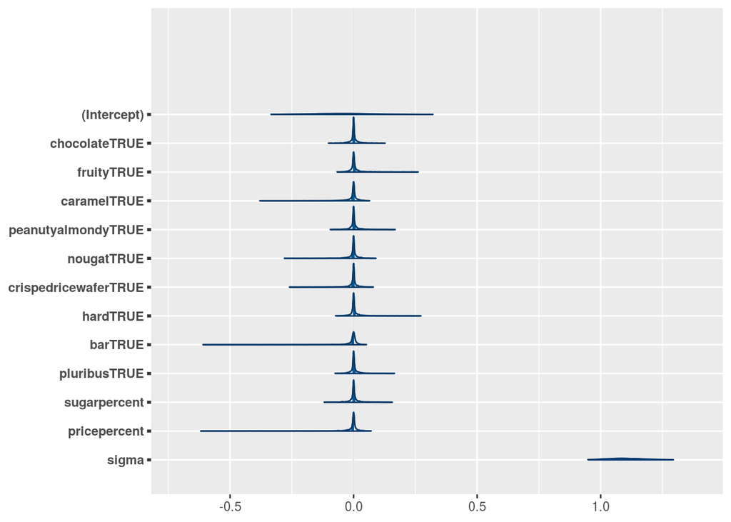

```r
mcmc_areas(as.matrix(fitrhs),prob_outer = .95)
```

All 95% posterior intervals are overlapping 0, regularized horseshoe prior makes the posteriors concentrate near 0, but there is some uncertainty.

We can easily test whether any of the covariates are useful by using cross-validation to compare to a null model,

```r
fit0 <- stan_glm(ry ~ 1, data = dfr, seed=SEED, refresh=0)
```

```r
(loorhs <- loo(fitrhs))
```

```
Computed from 4000 by 85 log-likelihood matrix

         Estimate   SE
elpd_loo   -130.1  6.2
p_loo         2.9  0.5
looic       260.2 12.4
------
Monte Carlo SE of elpd_loo is 0.0.

Pareto k diagnostic values:
                         Count Pct.    Min. n_eff
(-Inf, 0.5]   (good)     84    98.8%   1424
 (0.5, 0.7]   (ok)        1     1.2%   2573
   (0.7, 1]   (bad)       0     0.0%   <NA>
   (1, Inf)   (very bad)  0     0.0%   <NA>

All Pareto k estimates are ok (k < 0.7).
See help('pareto-k-diagnostic') for details.
```

```r
(loo0 <- loo(fit0))
```

```
Computed from 4000 by 85 log-likelihood matrix

         Estimate   SE
elpd_loo   -130.2  6.2
p_loo         1.9  0.4
looic       260.3 12.3
------
Monte Carlo SE of elpd_loo is 0.0.

All Pareto k estimates are good (k < 0.5).
See help('pareto-k-diagnostic') for details.
```

```r
loo_compare(loo0, loorhs)
```

```
       elpd_diff se_diff
fitrhs  0.0       0.0
fit0   -0.1       0.5
```

Based on cross-validation covariates together do not contain any useful information, and there is no need to continue with variable selection. This step of checking whether full mode has any predictive power is often ignored especially when non-Bayesian methods are used. If loo (or AIC as Joshua Loftus demonstrated) would be used for stepwise variable selection it is possible that selection process over a large number of models overfits to the data.

To illustrate the robustness of projpred, we make the projective predictive variable selection using the previous model for “null” data. A fast leave-one-out cross-validation approach (Vehtari, Gelman and Gabry, 2017) is used to choose the model size.

```r
fitrhs_cv <- cv_varsel(fitrhs, method='forward', cv_method='LOO', n_loo=n)
```

```r
fitrhs_cv$vind
```

```
             barTRUE          caramelTRUE         pricepercent
                   8                    3                   11
          fruityTRUE             hardTRUE         pluribusTRUE
                   2                    7                    9
crispedricewaferTRUE           nougatTRUE   peanutyalmondyTRUE
                   6                    5                    4
        sugarpercent        chocolateTRUE
                  10                    1
```

We can now look at the estimated predictive performance of smaller models compared to the full model.

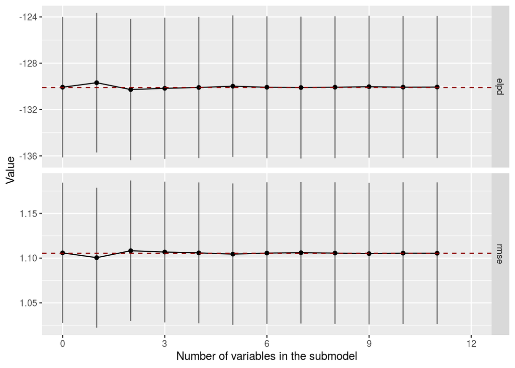

```r
varsel_plot(fitrhs_cv, stats = c('elpd', 'rmse'))
```

We can see that the differences to the full model are very small.

And we get a LOO based recommendation for the model size to choose

```r
(nv <- suggest_size(fitrhs_cv, alpha=0.1))
```

```
[1] 0
```

We see that projpred agrees that no variables have useful information.

Next we form the projected posterior for the chosen model.

```r
projrhs <- project(fitrhs_cv, nv = nv, ns = 4000)
round(colMeans(as.matrix(projrhs)),1)
```

```
(Intercept)       sigma
       -0.1         1.1
```

```r
round(posterior_interval(as.matrix(projrhs)),1)
```

```
              5% 95%
(Intercept) -0.3 0.1
sigma        1.0 1.3
```

This looks good as the true values for “null” data are intercept=0, sigma=1.

# 3 Original data

Next we repeat the above analysis with original target variable winpercent.

```r
fitrhs <- stan_glm(winpercent ~ ., data = df, prior=hs(), seed=SEED, refresh=0)
```

Let’s look at the summary:

```r
summary(fitrhs)
```

```
Model Info:
 function:     stan_glm
 family:       gaussian [identity]
 formula:      winpercent ~ .
 algorithm:    sampling
 sample:       4000 (posterior sample size)
 priors:       see help('prior_summary')
 observations: 85
 predictors:   12

Estimates:
                       mean   sd   10%   50%   90%
(Intercept)          41.3    3.5 36.7  41.7  45.4
chocolateTRUE        14.1    3.8  9.1  14.1  18.8
fruityTRUE            1.5    2.7 -0.8   0.5   5.5
caramelTRUE           0.7    2.1 -1.3   0.1   3.6
peanutyalmondyTRUE    4.4    3.8  0.0   4.2   9.5
nougatTRUE            0.4    2.5 -2.2   0.1   3.4
crispedricewaferTRUE  2.6    3.5 -0.4   1.3   7.7
hardTRUE             -2.0    2.7 -6.0  -1.0   0.4
barTRUE               1.1    2.5 -1.1   0.3   4.7
pluribusTRUE         -0.5    1.7 -2.8  -0.1   1.3
sugarpercent          2.9    3.6 -0.3   1.8   8.2
pricepercent          0.0    2.5 -2.9   0.0   2.7
sigma                11.3    1.0 10.1  11.2  12.5

Fit Diagnostics:
           mean   sd   10%   50%   90%
mean_PPD 50.4    1.7 48.1  50.3  52.5

The mean_ppd is the sample average posterior predictive distribution of the outcome variable (for details see help('summary.stanreg')).

MCMC diagnostics
                     mcse Rhat n_eff
(Intercept)          0.1  1.0  2813
chocolateTRUE        0.1  1.0  3055
fruityTRUE           0.1  1.0  2229
caramelTRUE          0.0  1.0  3832
peanutyalmondyTRUE   0.1  1.0  1408
nougatTRUE           0.0  1.0  4116
crispedricewaferTRUE 0.1  1.0  1747
hardTRUE             0.1  1.0  1850
barTRUE              0.0  1.0  3703
pluribusTRUE         0.0  1.0  4867
sugarpercent         0.1  1.0  1877
pricepercent         0.0  1.0  4292
sigma                0.0  1.0  2813
mean_PPD             0.0  1.0  4345
log-posterior        0.2  1.0   976

For each parameter, mcse is Monte Carlo standard error, n_eff is a crude measure of effective sample size, and Rhat is the potential scale reduction factor on split chains (at convergence Rhat=1).
```

We didn’t get divergences, Rhat’s are less than 1.1 and n_eff’s are useful.

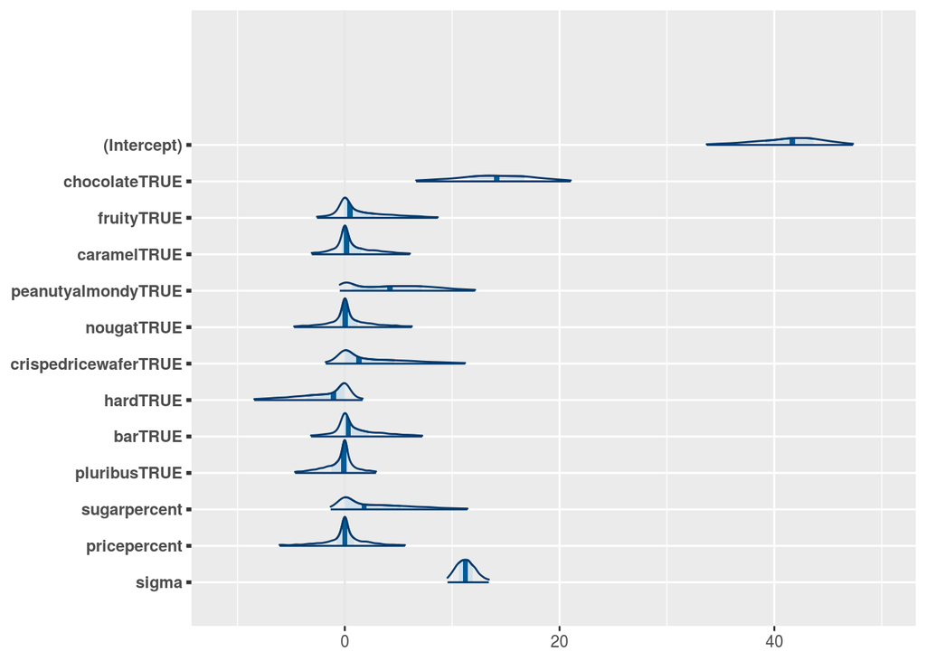

```r
mcmc_areas(as.matrix(fitrhs), prob_outer = .95)
```

95% posterior interval for `chocolateTRUE` is not overlapping 0, so maybe there is something useful here.

In case of collinear variables it is possible that marginal posteriors overlap 0, but the covariates can still useful for prediction. With many variables it will be difficult to analyse joint posterior to see which variables are jointly relevant. We can easily test whether any of the covariates are useful by using cross-validation to compare to a null model,

```r
fit0 <- stan_glm(winpercent ~ 1, data = df, seed=SEED, refresh=0)
```

```r
(loorhs <- loo(fitrhs))
```

```
Computed from 4000 by 85 log-likelihood matrix

         Estimate   SE
elpd_loo   -330.0  5.8
p_loo         7.5  1.1
looic       660.1 11.5
------
Monte Carlo SE of elpd_loo is 0.1.

Pareto k diagnostic values:
                         Count Pct.    Min. n_eff
(-Inf, 0.5]   (good)     84    98.8%   1116
 (0.5, 0.7]   (ok)        1     1.2%   513
   (0.7, 1]   (bad)       0     0.0%   <NA>
   (1, Inf)   (very bad)  0     0.0%   <NA>

All Pareto k estimates are ok (k < 0.7).
See help('pareto-k-diagnostic') for details.
```

```r
(loo0 <- loo(fit0))
```

```
Computed from 4000 by 85 log-likelihood matrix

         Estimate   SE
elpd_loo   -350.5  5.5
p_loo         1.6  0.3
looic       700.9 11.1
------
Monte Carlo SE of elpd_loo is 0.0.

All Pareto k estimates are good (k < 0.5).
See help('pareto-k-diagnostic') for details.
```

```r
loo_compare(loo0, loorhs)
```

```
       elpd_diff se_diff
fitrhs   0.0       0.0
fit0   -20.4       4.6
```

Based on cross-validation covariates together do contain useful information. If we need just the predictions we can stop here, but if we want to learn more about the relevance of the covariates we can continue with variable selection.

We make the projective predictive variable selection using the previous model for “null” data. A fast leave-one-out cross-validation approach is used to choose the model size.

```r
fitrhs_cv <- cv_varsel(fitrhs, method='forward', cv_method='LOO')
```

```r
fitrhs_cv$vind
```

```
       chocolateTRUE   peanutyalmondyTRUE crispedricewaferTRUE
                   1                    4                    6
        sugarpercent             hardTRUE              barTRUE
                  10                    7                    8
          fruityTRUE          caramelTRUE         pluribusTRUE
                   2                    3                    9
          nougatTRUE         pricepercent
                   5                   11
```

We can now look at the estimated predictive performance of smaller models compared to the full model.

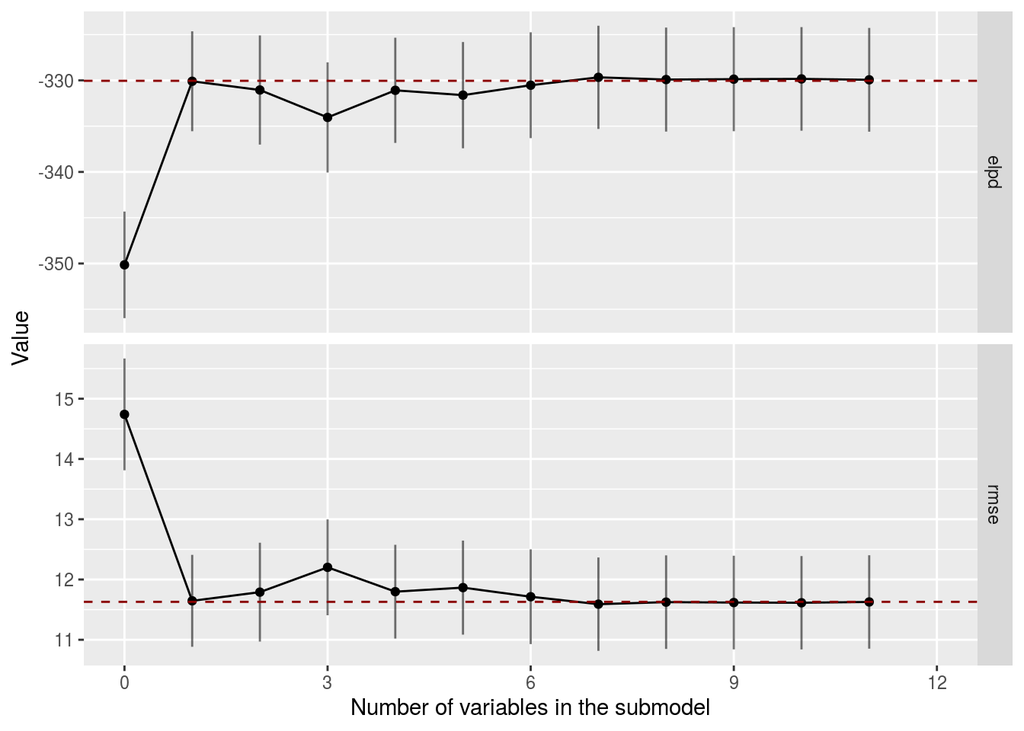

```r
varsel_plot(fitrhs_cv, stats = c('elpd', 'rmse'))
```

Only one variable seems to be needed to get the same performance as the full model.

And we get a LOO based recommendation for the model size to choose

```r
(nv <- suggest_size(fitrhs_cv, alpha=0.1))
```

```
[1] 1
```

projpred recommends to use just one variable.

Next we form the projected posterior for the chosen model.

```r
projrhs <- project(fitrhs_cv, nv = nv, ns = 4000)
round(colMeans(as.matrix(projrhs)),1)
```

```
  (Intercept) chocolateTRUE         sigma
         43.2          16.3          11.8
```

```r
round(posterior_interval(as.matrix(projrhs)),1)
```

```
                5%  95%
(Intercept)   40.5 46.0
chocolateTRUE 11.8 20.6
sigma         10.3 13.4
```

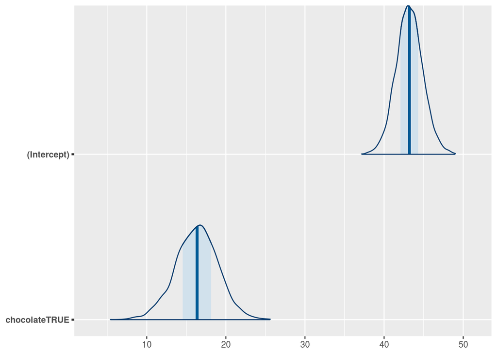

```r
mcmc_areas(as.matrix(projrhs),
           pars = c('(Intercept)', names(fitrhs_cv$vind[1])))
```

In our loo and projpred analysis, we find the `chocolateTRUE` to have predictive information. Other variables may have predictive power, too, but conditionally on `chocolateTRUE` other variables do not provide additional information.

# References

Piironen, J., Paasiniemi, M. and Vehtari, A. (2018) ‘Projective inference in high-dimensional problems: Prediction and feature selection’, *arXiv preprint arXiv:1810.02406*. Available at: https://arxiv.org/abs/1810.02406.

Piironen, J. and Vehtari, A. (2017a) ‘Comparison of Bayesian predictive methods for model selection’, *Statistics and Computing*, 27(3), pp. 711–735. doi: 10.1007/s11222-016-9649-y.

Piironen, J. and Vehtari, A. (2017b) ‘Sparsity information and regularization in the horseshoe and other shrinkage priors’, *Electronic journal of Statistics*, 11(2), pp. 5018–5051. doi: 10.1214/17-EJS1337SI.

Vehtari, A., Gelman, A. and Gabry, J. (2017) ‘Practical Bayesian model evaluation using leave-one-out cross-validation and WAIC’, *Statistics and Computing*, 27(5), pp. 1413–1432. doi: 10.1007/s11222-016-9696-4.

# Licenses

- Code © 2017-2018, Aki Vehtari, licensed under BSD-3.
- Text © 2017-2018, Aki Vehtari, licensed under CC-BY-NC 4.0.